# Project: Investigate a Dataset (Replace this with something more specific!)

## Data Cleaning

### Step 1: Remove duplicate rows from dataframe

```python
df.drop_duplicates(inplace = True)
```

### Check that there are no duplicates in the dataframe

```python
sum(df.duplicated())
```

```
0
```

### Step 1: Convert 'release_date' to datetime from 'object' (string)

```python
df['release_date']=pd.to_datetime(df['release_date'],format='%m/%d/%y')
pd.options.mode.chained_assignment = None
```

```python
df.head(2)
```

|  | popularity | original_title | director | runtime | genres | production_companies | release_date | vote_count | vote_average | release_year | budget_adj | revenue_adj |
| --- | --- | --- | --- | --- | --- | --- | --- | --- | --- | --- | --- | --- |
| 0 | 32.985763 | Jurassic World | Colin Trevorrow | 124.0 | Action\|Adventure\|Science Fiction\|Thriller | Universal Studios\|Amblin Entertainment\|Legenda... | 2015-06-09 | 5562 | 6.5 | 2015 | 1.379999e+08 | 1.392446e+09 |
| 1 | 28.419936 | Mad Max: Fury Road | George Miller | 120.0 | Action\|Adventure\|Science Fiction\|Thriller | Village Roadshow Pictures\|Kennedy Miller Produ... | 2015-05-13 | 6185 | 7.1 | 2015 | 1.379999e+08 | 3.481613e+08 |

### Checking convrsion of data types

```python
df.dtypes
```

```
popularity                     float64
original_title                  object
director                        object
runtime                        float64
genres                          object
production_companies            object
release_date            datetime64[ns]
vote_count                       int64
vote_average                   float64
release_year                     int64
budget_adj                     float64
revenue_adj                    float64
dtype: object
```

### Step 3: Remove Missing Values

```python
col_missing = ['director', 'runtime', 'genres']
df.dropna(subset=col_missing, inplace=True)
```

```python
df.info()
```

```
<class 'pandas.core.frame.DataFrame'>
Int64Index: 10772 entries, 0 to 10865
Data columns (total 12 columns):
popularity              10772 non-null float64
original_title          10772 non-null object
director                10772 non-null object
runtime                 10772 non-null float64
genres                  10772 non-null object
production_companies    9793 non-null object
release_date            10772 non-null datetime64[ns]
vote_count              10772 non-null int64
vote_average            10772 non-null float64
release_year            10772 non-null int64
budget_adj              5161 non-null float64
revenue_adj             4848 non-null float64
dtypes: datetime64[ns](1), float64(5), int64(2), object(4)
memory usage: 1.1+ MB
```

### Exploratory Data Analysis

### Question no. 1: How did the number of movies produced is changing over the years of the Dataset?

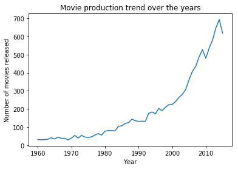

```python
#Number of movies produced each year
movies_per_year= df['release_year'].value_counts().sort_index();
plt.plot(movies_per_year);
plt.title('Movie production trend over the years');
plt.xlabel('Year');
plt.ylabel('Number of movies released');
```

###### From the figure above we can notice that there are some kind of exponential increase in the production of movies during the years covered by the data set

```python
#Years with maximum and minimum movie production
print("The maximum number of movies was produced in year ",movies_per_year.idxmax())  ,
print("The minimum number of movies was produced in year ",movies_per_year.idxmin())
```

```
The maximum number of movies was produced in year  2014
The minimum number of movies was produced in year  1961
```

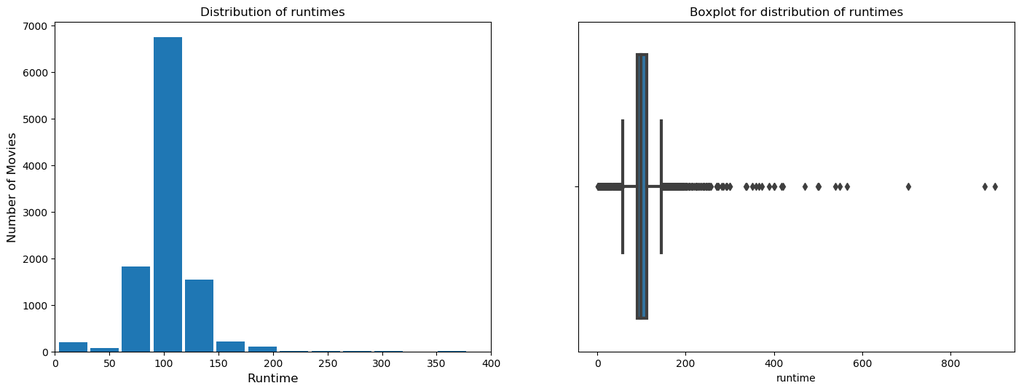

```python
fig = plt.figure(figsize = (17,6),dpi = 100);
fig.add_subplot(1,2,1)
plt.hist(df['runtime'],bins = 31, rwidth = 0.9);
plt.xlabel('Runtime', fontsize = 12);
plt.ylabel('Number of Movies', fontsize = 12);
plt.title('Distribution of runtimes', fontsize = 12);
plt.xlim(0,400);

fig.add_subplot(1,2,2);
sns.boxplot(df['runtime'],linewidth = 3);
plt.title('Boxplot for distribution of runtimes', fontsize = 12);
```

- from bar chart we notice that movies with run time 100 mins are the most produced.
- from box plot we can see that there are a lot of outliers

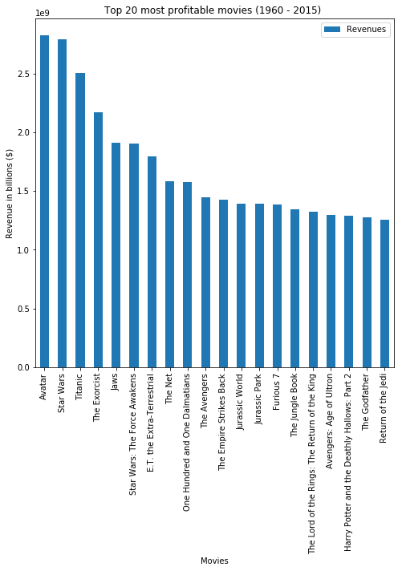

```python
sorted_revenue = df['revenue_adj'].sort_values(ascending=False)[:20]

top_profitable=pd.DataFrame()
titles=[]
revenues=[]
for i in sorted_revenue.index:
    titles.append(df.loc[i,'original_title'])
    revenues.append(sorted_revenue.loc[i])
top_profitable['Movies']=titles
top_profitable['Revenues']=revenues
top_profitable.set_index('Movies',inplace=True)
top_profitable.plot(kind ='bar',figsize=(8,8))
plt.title('Top 20 most profitable movies (1960 - 2015) ');
plt.ylabel('Revenue in billions ($)');
```

### Question no. 4: What are the top 20 movies with the highest budget?

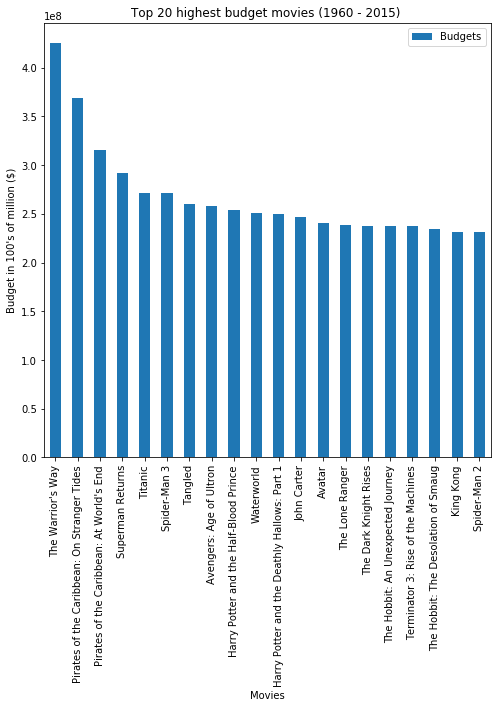

```python
sorted_budget = df['budget_adj'].sort_values(ascending=False)[:20]
high_budget=pd.DataFrame()
titles_exp=[]
budgets=[]
for i in sorted_budget.index:
    titles_exp.append(df.loc[i,'original_title'])
    budgets.append(sorted_budget.loc[i])
high_budget['Movies']=titles_exp
high_budget['Budgets']=budgets
high_budget.set_index('Movies',inplace=True)
high_budget.plot(kind ='bar',figsize=(8,8))
plt.title('Top 20 highest budget movies (1960 - 2015) ');
plt.ylabel('Budget in 100\'s of million ($)');
```

### Question no. 5: Do higher budget movies have higher revenue?

```python
cols=['budget_adj','revenue_adj','release_date']
df2=df[(df['budget_adj']>0) & (df['revenue_adj']>0)]
df2.shape
```

```
(3853, 12)
```

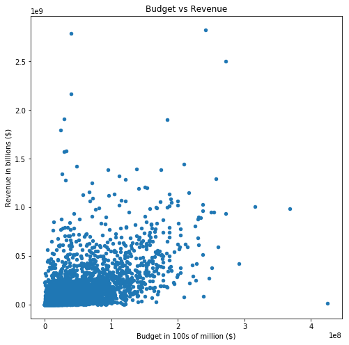

```python
df2.plot(x='budget_adj',y='revenue_adj',kind='scatter',figsize=(8,8));
plt.title('Budget vs Revenue')
plt.xlabel('Budget in 100s of million ($)');
plt.ylabel('Revenue in billions ($)');
```

###### It seems that there are some positive correlation between Budget and Revenue

### Question no 6: Do certain months of release associate with better revenues?

##### Extract the month of release for every movie in a new column

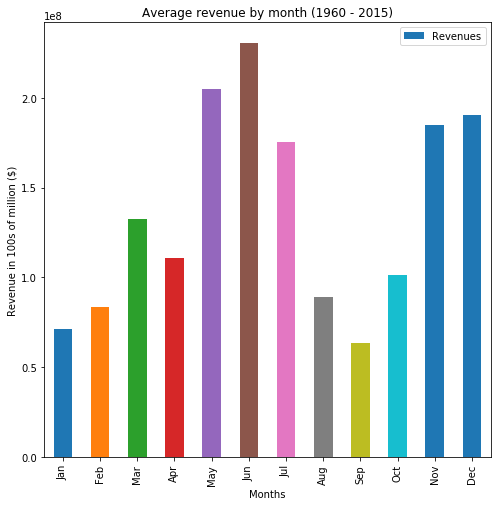

```python
df2['release_month']=df2['release_date'].dt.month

revenue_by_month = df2.groupby('release_month')['revenue_adj'].mean()
df3=pd.DataFrame()
months=['Jan','Feb','Mar','Apr','May','Jun','Jul','Aug','Sep','Oct','Nov','Dec']
df3['Months']=months
df3['Revenues'] = list(revenue_by_month.get_values())
df3.plot(x='Months',y='Revenues',kind='bar',figsize=(8,8));
plt.title('Average revenue by month (1960 - 2015)');
plt.ylabel('Revenue in 100s of million ($)');
```

### Question no. 7: Which months have seen the maximum releases?

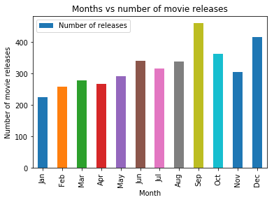

```python
numreleases_month= df2.release_month.value_counts().sort_index()
df4=pd.DataFrame()
df4['Months']=months
df4['Number of releases']=numreleases_month.get_values()
df4.plot(x='Months',y='Number of releases',kind='bar');
plt.title('Months vs number of movie releases');
plt.ylabel('Number of movie releases');
plt.xlabel('Month');
```

###### From bar chart we can see that most of movies have been released in september.

## Conclusions

#### 1- How did the number of movies produced is changing over the years of the Dataset?

- From the figure above we can notice that there are some kind of exponential increase in the production of movies during the years covered by the data set
- The maximum number of movies was produced in year 2014
- The minimum number of movies was produced in year 1961

- from bar chart we notice that movies with run time 100 mins are the most produced.
- from box plot we can see that there are a lot of outliers

#### 4- What are the top 20 movies with the highest budget?

- From the bar chart we can see that the the highest budget movie in history was The Warrior's Way.

#### 5- Do higher budget movies have higher revenue?

- It seems that there are some positive correlation between Budget and Revenue.

#### 7-Which months have seen the maximum releases?

- From bar chart we can see that most of movies have been released in september.

## Limitations

During the Analysis of this Dataset, there were some osbstcales and limitation that i had solve and tackle. I can conclude them as follow: 1- there were more than 6000 missing values in the revenue and budget columns which i had to deal with and remove these missing values. unfortunately, after removing these values there we a big loss in the dataset and this may have decreased the accuracy of the analysis done on these two variables. 2- the date type was not defined in a way that i can work with so i changed its type.

```python
from subprocess import call
call(['python', '-m', 'nbconvert', 'Investigate_a_Dataset.ipynb'])
```